# compare_genes

2025-09-15

# Load libraries

```r
.libPaths(.Library)
library(tidyverse)
library(ComplexHeatmap)
library(pbapply)
library(rhdf5)
library(httpgd)
library(plotly)
library(pbapply)
source("/home/akollot/projects/CRC1588/dataset_integration/anglemania_benchmark/scripts/ggplot_utils.R")
library(glue)
library(corrplot)
today <- function() {
  format(Sys.Date(), "%Y%m%d")
}
```

# Load data

```r
gene_files <- list.files("/data/akalin/akollot/anglemania_benchmark/simulated/facScale0.1/groupCells1000/preprocessed", full.names = TRUE)
samplesheet <- read.csv("/local/Projects/AAkalin_Neuroblastoma/Results/simulate_single_cell/samplesheet_facScale0.1.tsv", sep = "\t")
zscore_mean_threshold <- 2.5
zscore_snr_threshold <- 2.5
find_matching_files <- function(sample_name, files) {
  matching_files <- grep(sample_name, files, value = TRUE)
  return(matching_files)
}

expanded <- samplesheet %>%
    rowwise() %>%
    mutate(tsv_files = list(find_matching_files(sample_name, gene_files))) %>%
    tidyr::unnest(tsv_files) %>%
    rowwise() %>%
    mutate(gene_selection = case_when(
      grepl("_full.tsv", tsv_files) ~ "full",
      grepl("_hvg.tsv", tsv_files) ~ "hvg",
      grepl("_rand.tsv", tsv_files) ~ "rand",
      grepl("_angl.tsv", tsv_files) ~ "angl"
    ),
           gene_selection = factor(gene_selection, levels = c("full", "hvg", "rand", "angl"))) %>%
    ungroup() %>%
    filter(!is.na(gene_selection))
```

```r
outplot <- "/home/akollot/projects/CRC1588/dataset_integration/anglemania_benchmark/output/plots/compare_gene_selections/facScale0.1/groupCells1000/"
if (!dir.exists(outplot)) {
  dir.create(outplot, recursive = TRUE)
}
```

# Plot intersection size of HVGs and anglemania genes

```r
result <- expanded %>%
  filter(gene_selection %in% c("hvg", "angl")) %>%
  group_by(sample_name) %>%
  mutate(group_size = n()) %>%
         filter(group_size > 1)

result <- result %>%
  pivot_wider(names_from = gene_selection, values_from = tsv_files) %>%
  rowwise() %>%
  dplyr::mutate(angl = list(read.csv(angl, sep = "\t", header = T) %>% pull(hgnc_symbol)),
         hvg = list(read.csv(hvg, sep = "\t", header = T) %>% pull(hgnc_symbol)))
# saveRDS(result, file = "/home/akollot/projects/CRC1588/dataset_integration/anglemania_benchmark/output/compare_gene_selections_result.RDS")
# result <- readRDS("/home/akollot/projects/CRC1588/dataset_integration/anglemania_benchmark/output/compare_gene_selections_result.RDS")
result <- result %>%
  filter(
    de.facLoc != 0.001,
    batch.facLoc != 0.001
  ) %>%
  mutate(
    de.facLoc = case_when(
      de.facLoc == 0 ~ "none",
      de.facLoc == 0.01 ~ "small",
      de.facLoc == 0.05 ~ "mild",
      de.facLoc == 0.1 ~ "moderate",
      de.facLoc == 0.3 ~ "strong",
      de.facLoc == 0.6 ~ "very strong"
    ),
    de.facLoc = factor(de.facLoc, levels = c("none", "small", "mild", "moderate", "strong", "very strong")),
    batch.facLoc = case_when(
      batch.facLoc == 0 ~ "none",
      batch.facLoc == 0.01 ~ "small",
      batch.facLoc == 0.05 ~ "mild",
      batch.facLoc == 0.1 ~ "moderate",
      batch.facLoc == 0.3 ~ "strong",
      batch.facLoc == 0.6 ~ "very strong"
    ),
    batch.facLoc = factor(batch.facLoc, levels = c("none", "small", "mild", "moderate", "strong", "very strong"))
  )
head(result)
```

| sample_name | original_h5ad | batch.facLoc | de.facLoc | nbatch | ngroup | groupCells | nGenes | de.facScale | file_path | group_size | angl | hvg |
| --- | --- | --- | --- | --- | --- | --- | --- | --- | --- | --- | --- | --- |
| batch.facLoc0_de.facLoc0_nbatch2_ngroup2_groupCells1000 | /local/Projects/AAkalin_Neuroblastoma/Results/simulate_single_cell/h5ad/facScale0.1/batch.facLoc0_de.facLoc0_nbatch2_ngroup2_groupCells1000.h5ad | none | none | 2 | 2 | 1000 | 10000 | 0.1 | /local/Projects/AAkalin_Neuroblastoma/Results/simulate_single_cell/h5ad/facScale0.1/batch.facLoc0_de.facLoc0_nbatch2_ngroup2_groupCells1000.h5ad | 2 |  |  |
| batch.facLoc0.01_de.facLoc0_nbatch2_ngroup2_groupCells1000 | /local/Projects/AAkalin_Neuroblastoma/Results/simulate_single_cell/h5ad/facScale0.1/batch.facLoc0.01_de.facLoc0_nbatch2_ngroup2_groupCells1000.h5ad | small | none | 2 | 2 | 1000 | 10000 | 0.1 | /local/Projects/AAkalin_Neuroblastoma/Results/simulate_single_cell/h5ad/facScale0.1/batch.facLoc0.01_de.facLoc0_nbatch2_ngroup2_groupCells1000.h5ad | 2 |  |  |
| batch.facLoc0.05_de.facLoc0_nbatch2_ngroup2_groupCells1000 | /local/Projects/AAkalin_Neuroblastoma/Results/simulate_single_cell/h5ad/facScale0.1/batch.facLoc0.05_de.facLoc0_nbatch2_ngroup2_groupCells1000.h5ad | mild | none | 2 | 2 | 1000 | 10000 | 0.1 | /local/Projects/AAkalin_Neuroblastoma/Results/simulate_single_cell/h5ad/facScale0.1/batch.facLoc0.05_de.facLoc0_nbatch2_ngroup2_groupCells1000.h5ad | 2 |  |  |
| batch.facLoc0.1_de.facLoc0_nbatch2_ngroup2_groupCells1000 | /local/Projects/AAkalin_Neuroblastoma/Results/simulate_single_cell/h5ad/facScale0.1/batch.facLoc0.1_de.facLoc0_nbatch2_ngroup2_groupCells1000.h5ad | moderate | none | 2 | 2 | 1000 | 10000 | 0.1 | /local/Projects/AAkalin_Neuroblastoma/Results/simulate_single_cell/h5ad/facScale0.1/batch.facLoc0.1_de.facLoc0_nbatch2_ngroup2_groupCells1000.h5ad | 2 |  |  |
| batch.facLoc0.3_de.facLoc0_nbatch2_ngroup2_groupCells1000 | /local/Projects/AAkalin_Neuroblastoma/Results/simulate_single_cell/h5ad/facScale0.1/batch.facLoc0.3_de.facLoc0_nbatch2_ngroup2_groupCells1000.h5ad | strong | none | 2 | 2 | 1000 | 10000 | 0.1 | /local/Projects/AAkalin_Neuroblastoma/Results/simulate_single_cell/h5ad/facScale0.1/batch.facLoc0.3_de.facLoc0_nbatch2_ngroup2_groupCells1000.h5ad | 2 |  |  |
| batch.facLoc0.6_de.facLoc0_nbatch2_ngroup2_groupCells1000 | /local/Projects/AAkalin_Neuroblastoma/Results/simulate_single_cell/h5ad/facScale0.1/batch.facLoc0.6_de.facLoc0_nbatch2_ngroup2_groupCells1000.h5ad | very strong | none | 2 | 2 | 1000 | 10000 | 0.1 | /local/Projects/AAkalin_Neuroblastoma/Results/simulate_single_cell/h5ad/facScale0.1/batch.facLoc0.6_de.facLoc0_nbatch2_ngroup2_groupCells1000.h5ad | 2 |  |  |

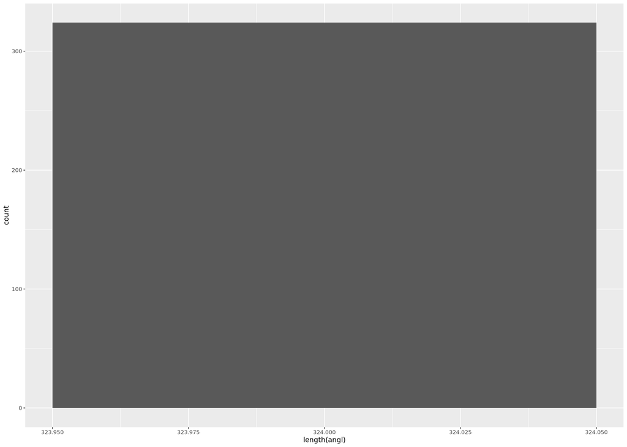

```r
result %>%
  ggplot(aes(length(angl)))+
  geom_histogram()
```

```r
for_plot <- result %>%
  rowwise() %>%
  mutate(intersection = list(intersect(angl, hvg)),
    intersection_size = length(intersection),
    intersection_size_perc = intersection_size / length(angl)*100) %>%
    select(-angl, -hvg)
colnames(for_plot)
```

```
##  [1] "sample_name"            "original_h5ad"          "batch.facLoc"
##  [4] "de.facLoc"              "nbatch"                 "ngroup"
##  [7] "groupCells"             "nGenes"                 "de.facScale"
## [10] "file_path"              "group_size"             "intersection"
## [13] "intersection_size"      "intersection_size_perc"
```

```r
colnames(result)
```

```
##  [1] "sample_name"   "original_h5ad" "batch.facLoc"  "de.facLoc"
##  [5] "nbatch"        "ngroup"        "groupCells"    "nGenes"
##  [9] "de.facScale"   "file_path"     "group_size"    "angl"
## [13] "hvg"
```

```r
cor_plot <- for_plot %>%
  select(
    where(is.numeric),
    de.facLoc, batch.facLoc,
    -groupCells, -group_size
  ) %>%
  mutate(across(everything(), as.numeric))

corrs <- cor(cor_plot$intersection_size_perc, cor_plot%>% select(-intersection_size, -intersection_size_perc))
corrs
```

```
##           nbatch      ngroup nGenes de.facScale de.facLoc batch.facLoc
## [1,] -0.01089612 -0.08069762     NA          NA 0.5904857  -0.01465752
```

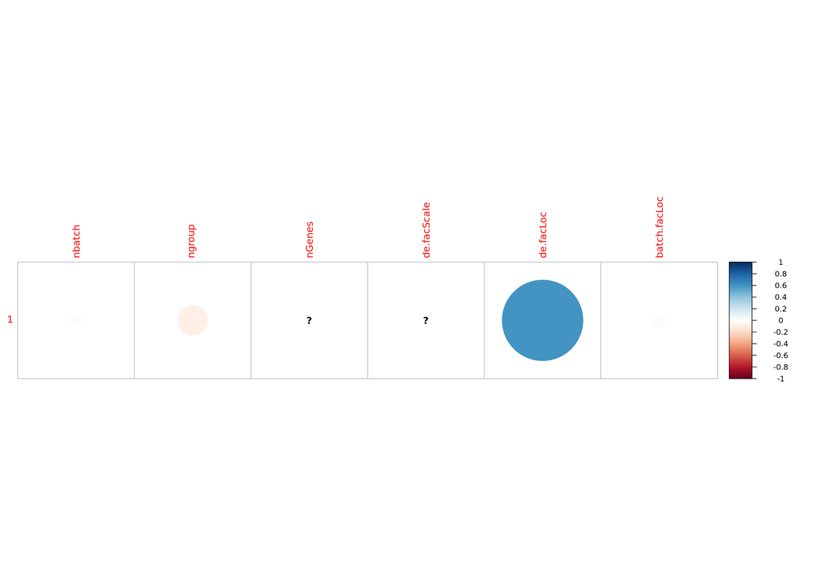

```r
library(corrplot)
corrplot(corrs, method = "circle")
```

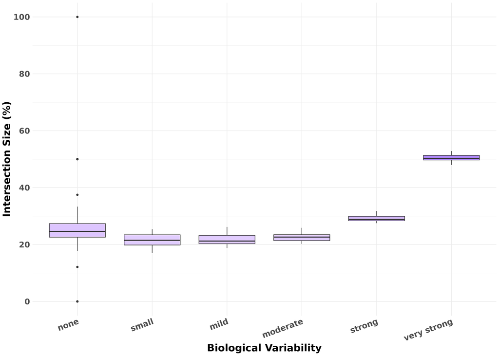

```r
p <- for_plot %>%
  ungroup() %>%
  group_by(de.facLoc) %>%
  mutate(median_intersection_size = median(intersection_size_perc)) %>%
  ggplot(aes(as.factor(de.facLoc), intersection_size_perc))+
  geom_boxplot(aes(fill = median_intersection_size)) +
  labs(x = "Biological Variability", y = "Intersection Size (%)") +
  # manually adjust tick labels
  scale_y_continuous(breaks = c(0, 20, 40, 60, 80, 100), limits = c(0,100))+
  scale_fill_continuous(low = "white", high = "blue", limits = c(0, 100)) +
  theme_minimal() +
  # ggtitle("Percent of anglemania genes that intersect with HVG. Plotted against biological variability.")+
  theme(text = element_text(size = 20, face = "bold"),
        legend.position = "none",
        axis.text.x = element_text(angle = 20, hjust = 1))
p
```

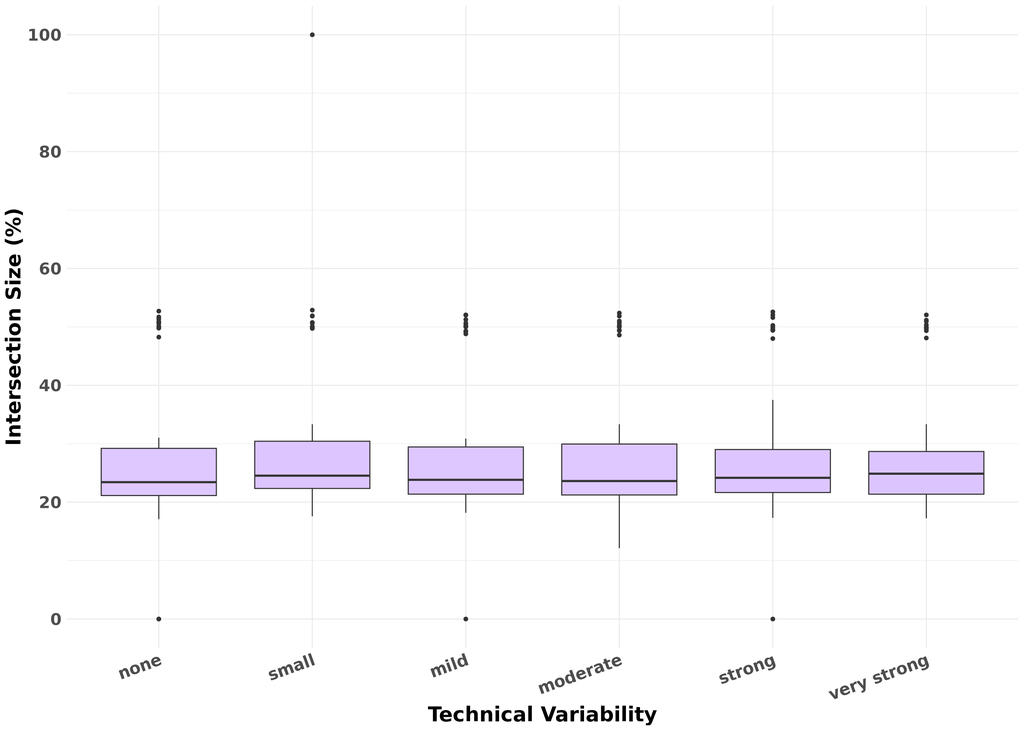

```r
ggsave(
  file = file.path(outplot, glue("{today()}_Biological_Variability_vs_intersection_size.pdf")),
  plot = p,
  width = 6,
  height = 5
)

p <- for_plot %>%
  ungroup() %>%
    group_by(batch.facLoc) %>%
    mutate(median_intersection_size = median(intersection_size_perc)) %>%
    ggplot(aes(as.factor(batch.facLoc), intersection_size_perc)) +
      geom_boxplot(aes(fill = median_intersection_size)) +
      labs(x = "Technical Variability", y = "Intersection Size (%)") +
      # manually adjust tick labels
      scale_y_continuous(breaks = c(0, 20, 40, 60, 80, 100), limits = c(0, 100)) +
      scale_fill_continuous(low = "white", high = "blue", limits = c(0, 100)) +
      theme_minimal() +
      # ggtitle("PercenRt of anglemania genes that intersect with HVG. Plotted against biological variability.")+
      theme(
        text = element_text(size = 20, face = "bold"),
        legend.position = "none",
        axis.text.x = element_text(angle = 20, hjust = 1)
  )
p
```

```r
ggsave(
  file = file.path(outplot, glue("{today()}_Technical_Variability_vs_intersection_size.pdf")),
  plot = p,
  width = 6,
  height = 5)
```

# Calculate BTVR

```r
library(scales)
get_rowData <- function(sim_h5ad_path){
  df <- h5read(sim_h5ad_path, "/var") %>% as.data.frame() %>% column_to_rownames("X_index")
  return(df)
}

get_BTVR <- function(rowdata) {
  # Calculate BioVar and TechVar using vectorized operations
  bio_var_cols <- dplyr::select(rowdata, starts_with("DEFacGroup"))
  tech_var_cols <- dplyr::select(rowdata, starts_with("BatchFacBatch"))

  # Use apply function to compute variances row-wise
  raw_BioVar <- apply(bio_var_cols, 1, var)
  BioVar <- raw_BioVar
  BioVar[BioVar > 0] <- raw_BioVar[raw_BioVar > 0] %>%
    log() %>%
    rescale()
  raw_TechVar <- apply(tech_var_cols, 1, var)
  TechVar <- raw_TechVar
  TechVar[TechVar > 0] <- raw_TechVar[raw_TechVar > 0] %>%
    log() %>%
    rescale()

  # TechVar <- raw_TechVar %>%
  #   log() %>%
  #   rescale()

  # Compute BTVR directly
  BTVR <- log(raw_BioVar + 1e-15 / raw_TechVar + 1e-15) %>% rescale()
  GeneScore <- BTVR * BioVar #basically "scaled" by BioVar

  # Create result tibble
  summary_df <- tibble(
    gene = rownames(rowdata),
    BTVR = BTVR,
    GeneScore = GeneScore,
    raw_BioVar = raw_BioVar,
    BioVar = BioVar,
    raw_TechVar = raw_TechVar,
    TechVar = TechVar,
    GeneMean = rowdata$GeneMean
  )

  return(summary_df)
}

get_BTVR2 <- function(rowdata) {
  # 1. Identify columns for biology and technical factors
  bio_var_cols <- dplyr::select(rowdata, starts_with("DEFacGroup"))
  tech_var_cols <- dplyr::select(rowdata, starts_with("BatchFacBatch"))

  # 2. Compute row-wise variance
  bio_var <- apply(bio_var_cols, 1, var)
  tech_var <- apply(tech_var_cols, 1, var)

  # 3. Total variance (ignoring interaction)
  total_var <- bio_var + tech_var

  # 4. Fractions of total variance
  bio_frac <- bio_var / total_var
  tech_frac <- tech_var / total_var
  BioVar <- bio_var
  BioVar[BioVar > 0] <- log(BioVar[BioVar > 0])
  BioVar <- BioVar %>% rescale()
  TechVar <- tech_var %>% log() %>% rescale()
  # Compute BTVR directly
  BTVR <- BioVar/TechVar
  # If total_var = 0 for some genes (e.g., all factors = 1), these become NaN;
  # you could set them to 0 or handle them as you like.
  # Create result tibble
  summary_df <- tibble(
    gene = rownames(rowdata),
    BioVar = bio_var,
    TechVar = tech_var,
    TotalVar = total_var,
    BioFrac = bio_frac,   # fraction of total variance that is biological
    TechFrac = tech_frac,
    BTVR = BTVR
  )

  return(summary_df)
}
```

```r
btvr <- expanded %>%
  filter(gene_selection %in% c("hvg", "angl")) %>%
  group_by(sample_name) %>%
  mutate(group_size = n()) %>%
         filter(group_size > 1) %>% # make sure to only include the samples that have both the angl and hvg genes already calculated (snakemake pipeline preprocess)
  pivot_wider(names_from = gene_selection, values_from = tsv_files)

# construct nested tibble but don't use tidyverse cause it's freaking slow
rowdatas <- pblapply(btvr$original_h5ad, get_rowData, cl = 20)
h5closeAll()
BTVR <- pblapply(rowdatas, get_BTVR, cl = 20)
angl <- pblapply(btvr$angl, function(x) {
  genes <- read.csv(x, sep = "\t", header = T) %>% pull(hgnc_symbol)
  }, cl = 20)
hvg <- pblapply(btvr$hvg, function(x) {
  genes <- read.csv(x, sep = "\t", header = T) %>% pull(hgnc_symbol)
  }, cl = 20)
btvr$BTVR <- BTVR
btvr$angl <- angl
btvr$hvg <- hvg

btvr_raw <- btvr
BTVR[[1]]
```

| gene | BTVR | GeneScore | raw_BioVar | BioVar | raw_TechVar | TechVar | GeneMean |
| --- | --- | --- | --- | --- | --- | --- | --- |
| Gene1 | NaN | NaN | 0 | 0 | 0 | 0 | 1.944969e+00 |
| Gene2 | NaN | NaN | 0 | 0 | 0 | 0 | 8.043543e+00 |
| Gene3 | NaN | NaN | 0 | 0 | 0 | 0 | 1.787970e+00 |
| Gene4 | NaN | NaN | 0 | 0 | 0 | 0 | 1.225598e+00 |
| Gene5 | NaN | NaN | 0 | 0 | 0 | 0 | 5.127994e-02 |
| Gene6 | NaN | NaN | 0 | 0 | 0 | 0 | 9.519532e-01 |
| Gene7 | NaN | NaN | 0 | 0 | 0 | 0 | 3.232874e-01 |
| Gene8 | NaN | NaN | 0 | 0 | 0 | 0 | 2.043138e+00 |
| Gene9 | NaN | NaN | 0 | 0 | 0 | 0 | 1.421195e-01 |
| Gene10 | NaN | NaN | 0 | 0 | 0 | 0 | 4.779354e+00 |

[output cut: 9990 more lines]

```r
test <- rowdatas[[5]]
# View(head(test, 2000))
# View(head(BTVR[[2]], 2000))
```

```r
btvr <- btvr_raw %>%
  mutate(btvr_dist = pmap(
list(angl, hvg, BTVR),
      ~ { genes <- unique(c(..1, ..2))
        # Create a tibble for genes with their BTVR values
        merged_tbl <- ..3 %>%
          dplyr::filter(gene %in% genes) %>%
          mutate(
            angl = gene %in% ..1,
            hvg = gene %in% ..2
          )
        # Return the new tibble
        merged_tbl} ))

btvr <- btvr %>%
  rowwise() %>%
  mutate(btvr_dist = list(btvr_dist %>% pivot_longer(cols = c(angl, hvg),
    names_to = "gene_selection",
    values_to = "is_selected") %>% filter(is_selected)))

# for (i in 1:10){
#   plot_df <- btvr[i, ]
#   # print(plot_df)
#   # print(plot_df$btvr_dist)
#   print(plot_df$btvr_dist %>%
#     as.data.frame() %>%
#     ggplot(aes(gene_selection, BTVR))+
#     geom_violin(aes(fill = gene_selection))+
#     ggtitle(paste0("Bio to Technical variability ratio. de.facLoc: ", plot_df$de.facLoc, " batch.facLoc: ", plot_df$batch.facLoc)))
# }
```

## Unnest and summarize the BTVR over the different nbatch, and ngroup combinations

- anglemania genes have a much higher BTVR (bio to technical variability) => this is great!

```r
unnested <- btvr %>%
  select(-BTVR, -angl, -hvg) %>%
  unnest(btvr_dist) %>%
  ungroup() %>%
  filter(!is.infinite(BTVR)) # there was one gene (!) that had 0 TechVar so BTVR was infinite, but really only 1 gene lol.
head(unnested)
```

| sample_name | original_h5ad | batch.facLoc | de.facLoc | nbatch | ngroup | groupCells | nGenes | de.facScale | file_path | group_size | gene | BTVR | GeneScore | raw_BioVar | BioVar | raw_TechVar | TechVar | GeneMean | gene_selection | is_selected |
| --- | --- | --- | --- | --- | --- | --- | --- | --- | --- | --- | --- | --- | --- | --- | --- | --- | --- | --- | --- | --- |
| batch.facLoc0_de.facLoc0_nbatch2_ngroup2_groupCells1000 | /local/Projects/AAkalin_Neuroblastoma/Results/simulate_single_cell/h5ad/facScale0.1/batch.facLoc0_de.facLoc0_nbatch2_ngroup2_groupCells1000.h5ad | 0 | 0 | 2 | 2 | 1000 | 10000 | 0.1 | /local/Projects/AAkalin_Neuroblastoma/Results/simulate_single_cell/h5ad/facScale0.1/batch.facLoc0_de.facLoc0_nbatch2_ngroup2_groupCells1000.h5ad | 2 | Gene1 | NaN | NaN | 0 | 0 | 0 | 0 | 1.94496950 | angl | TRUE |
| batch.facLoc0_de.facLoc0_nbatch2_ngroup2_groupCells1000 | /local/Projects/AAkalin_Neuroblastoma/Results/simulate_single_cell/h5ad/facScale0.1/batch.facLoc0_de.facLoc0_nbatch2_ngroup2_groupCells1000.h5ad | 0 | 0 | 2 | 2 | 1000 | 10000 | 0.1 | /local/Projects/AAkalin_Neuroblastoma/Results/simulate_single_cell/h5ad/facScale0.1/batch.facLoc0_de.facLoc0_nbatch2_ngroup2_groupCells1000.h5ad | 2 | Gene5 | NaN | NaN | 0 | 0 | 0 | 0 | 0.05127994 | angl | TRUE |
| batch.facLoc0_de.facLoc0_nbatch2_ngroup2_groupCells1000 | /local/Projects/AAkalin_Neuroblastoma/Results/simulate_single_cell/h5ad/facScale0.1/batch.facLoc0_de.facLoc0_nbatch2_ngroup2_groupCells1000.h5ad | 0 | 0 | 2 | 2 | 1000 | 10000 | 0.1 | /local/Projects/AAkalin_Neuroblastoma/Results/simulate_single_cell/h5ad/facScale0.1/batch.facLoc0_de.facLoc0_nbatch2_ngroup2_groupCells1000.h5ad | 2 | Gene5 | NaN | NaN | 0 | 0 | 0 | 0 | 0.05127994 | hvg | TRUE |
| batch.facLoc0_de.facLoc0_nbatch2_ngroup2_groupCells1000 | /local/Projects/AAkalin_Neuroblastoma/Results/simulate_single_cell/h5ad/facScale0.1/batch.facLoc0_de.facLoc0_nbatch2_ngroup2_groupCells1000.h5ad | 0 | 0 | 2 | 2 | 1000 | 10000 | 0.1 | /local/Projects/AAkalin_Neuroblastoma/Results/simulate_single_cell/h5ad/facScale0.1/batch.facLoc0_de.facLoc0_nbatch2_ngroup2_groupCells1000.h5ad | 2 | Gene8 | NaN | NaN | 0 | 0 | 0 | 0 | 2.04313783 | angl | TRUE |
| batch.facLoc0_de.facLoc0_nbatch2_ngroup2_groupCells1000 | /local/Projects/AAkalin_Neuroblastoma/Results/simulate_single_cell/h5ad/facScale0.1/batch.facLoc0_de.facLoc0_nbatch2_ngroup2_groupCells1000.h5ad | 0 | 0 | 2 | 2 | 1000 | 10000 | 0.1 | /local/Projects/AAkalin_Neuroblastoma/Results/simulate_single_cell/h5ad/facScale0.1/batch.facLoc0_de.facLoc0_nbatch2_ngroup2_groupCells1000.h5ad | 2 | Gene9 | NaN | NaN | 0 | 0 | 0 | 0 | 0.14211946 | hvg | TRUE |
| batch.facLoc0_de.facLoc0_nbatch2_ngroup2_groupCells1000 | /local/Projects/AAkalin_Neuroblastoma/Results/simulate_single_cell/h5ad/facScale0.1/batch.facLoc0_de.facLoc0_nbatch2_ngroup2_groupCells1000.h5ad | 0 | 0 | 2 | 2 | 1000 | 10000 | 0.1 | /local/Projects/AAkalin_Neuroblastoma/Results/simulate_single_cell/h5ad/facScale0.1/batch.facLoc0_de.facLoc0_nbatch2_ngroup2_groupCells1000.h5ad | 2 | Gene10 | NaN | NaN | 0 | 0 | 0 | 0 | 4.77935415 | hvg | TRUE |

```r
# unnested %>%
#   ggplot()
unnested %>%
  distinct(ngroup, nbatch)
```

| ngroup | nbatch |
| --- | --- |
| 2 | 2 |
| 2 | 4 |
| 2 | 5 |
| 4 | 2 |
| 4 | 4 |
| 4 | 5 |
| 5 | 2 |
| 5 | 4 |
| 5 | 5 |

```r
View(head(unnested, 5000))
# Summarize the data and pivot to wide format
summary_df_BTVR <- unnested %>%
  group_by(gene_selection, batch.facLoc, de.facLoc) %>%
  summarise(
    mean = mean(BTVR, na.rm = TRUE),
    median = median(BTVR, na.rm = TRUE),
    sd = sd(BTVR, na.rm = TRUE),
    n = n(),
    .groups = 'drop'  # Avoid unnecessary grouping
  )
```

# Plotting

## BTVR

### Mean

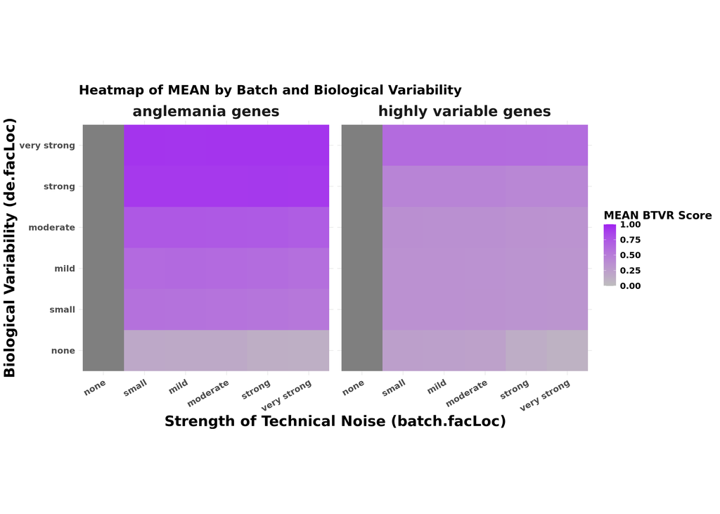

```r
# Plot heatmap
p <- unnested %>%
  draw_heatmap2(
    df = .,
    score = "BTVR",
    fill = "mean",
    scale_fill_limits = c(0, 1)
  )
p
```

```r
ggsave(
  file.path(
    "/home/akollot/projects/CRC1588/dataset_integration/anglemania_manuscript/plots/",
    glue("{today()}_mean_BTVR_heatmap.pdf")),
  width = 11,
  height = 8
)
ggsave(
  file.path(outplot, glue("{today()}_mean_BTVR_heatmap.pdf")),
  width = 11,
  height = 8
)
```

### Median

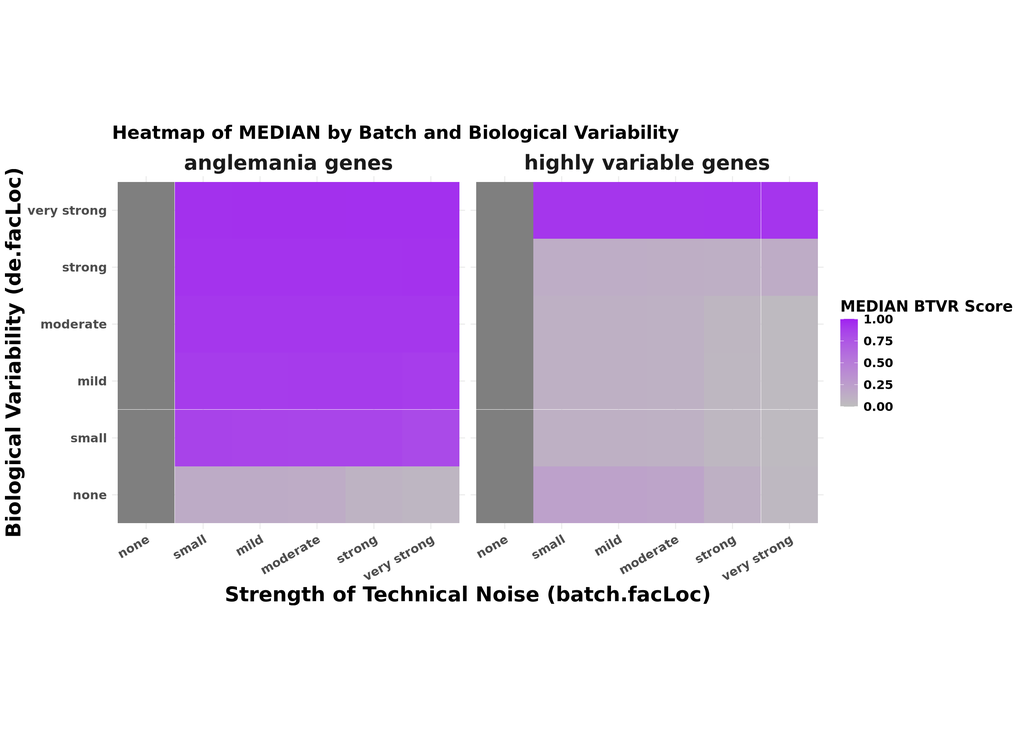

```r
p <- unnested %>%
  draw_heatmap2(
    df = .,
    score = "BTVR",
    fill = "median",
    scale_fill_limits = c(0, 1)
  )
p
```

```r
ggsave(
  file.path(
    "/home/akollot/projects/CRC1588/dataset_integration/anglemania_manuscript/plots/",
    glue("{today()}_median_BTVR_heatmap.pdf")),
  width = 11,
  height = 8
)
ggsave(
  file.path(outplot, glue("{today()}_median_BTVR_heatmap.pdf")),
  width = 11,
  height = 8
)
```

## BTVR scaled by BioVar

### Mean

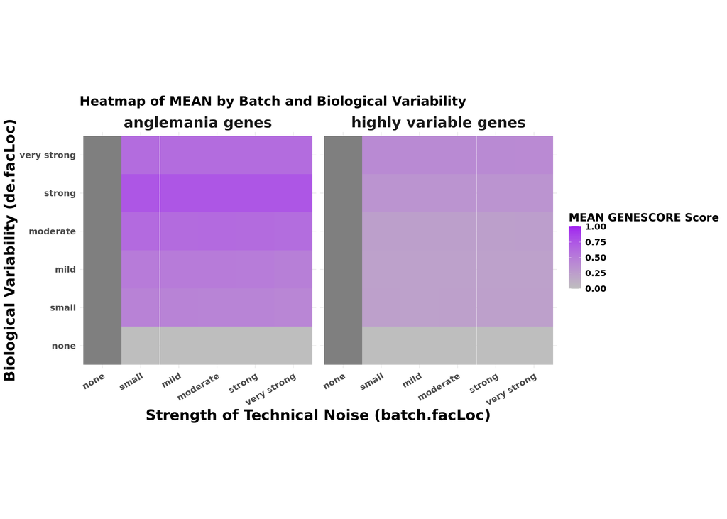

```r
# Summarize the data and pivot to wide format
p <- unnested %>%
  draw_heatmap2(
    df = .,
    score = "GeneScore",
    fill = "mean",
    scale_fill_limits = c(0, 1)
  )

p
```

```r
ggsave(
  file.path(
    "/home/akollot/projects/CRC1588/dataset_integration/anglemania_manuscript/plots/",
    glue("{today()}_mean_BTVR-Scaled-by-BioVar_heatmap.pdf")),
  width = 11,
  height = 8
)
ggsave(
  file.path(outplot, glue("{today()}_mean_BTVR-Scaled-by-BioVar_heatmap.pdf")),
  width = 11,
  height = 8
)
```

### Median

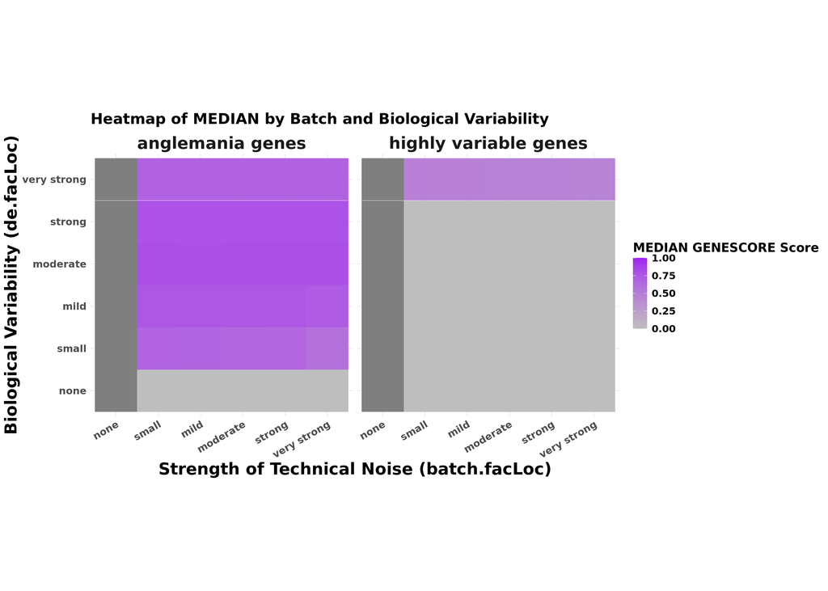

```r
p <- unnested %>%
  draw_heatmap2(
    df = .,
    score = "GeneScore",
    fill = "median",
    scale_fill_limits = c(0, 1)
  )

p
```

```r
ggsave(
  file.path(
    "/home/akollot/projects/CRC1588/dataset_integration/anglemania_manuscript/plots/",
    glue("{today()}_median_BTVR-Scaled-by-BioVar_heatmap.pdf")),
  width = 11,
  height = 8
)
ggsave(
  file.path(outplot, glue("{today()}_median_BTVR-Scaled-by-BioVar_heatmap.pdf")),
  width = 11,
  height = 8
)
```

## BioVar

- it looks like the higher BTVR is due to the fact that angelmania captures genes with high biological variability!

### Mean

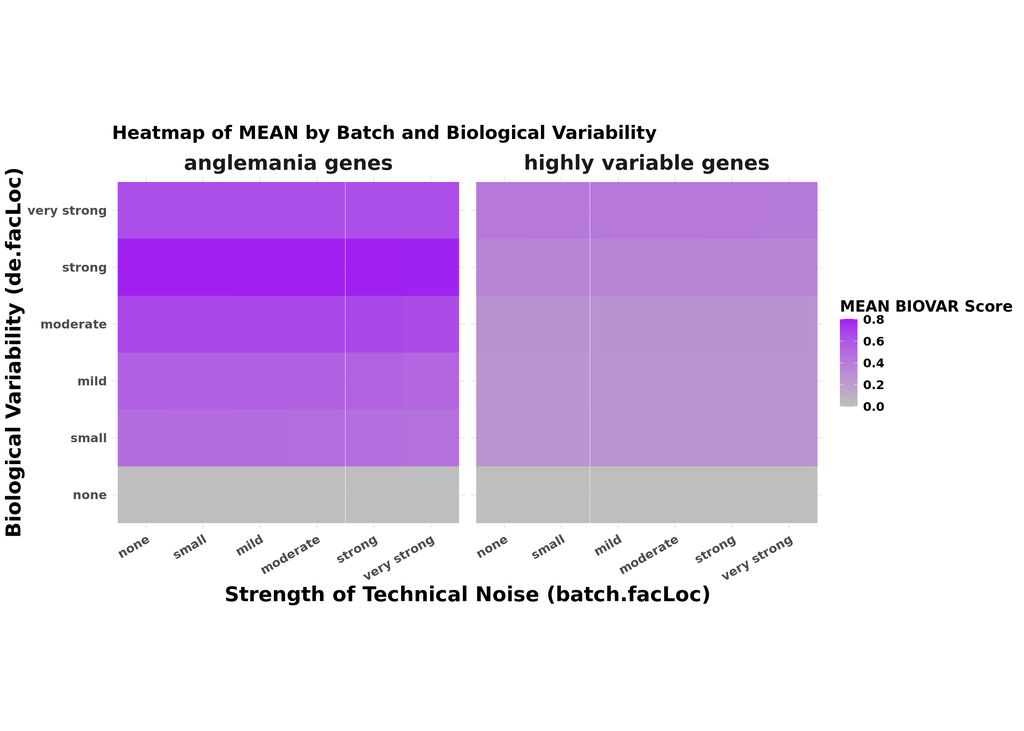

```r
p <- unnested %>%
  draw_heatmap2(
    df = .,
    score = "BioVar",
    fill = "mean"
  )
p
```

```r
ggsave(
  file.path(outplot, glue("{today()}_mean_BioVar_heatmap.pdf")),
  width = 11,
  height = 8
)
```

### Median

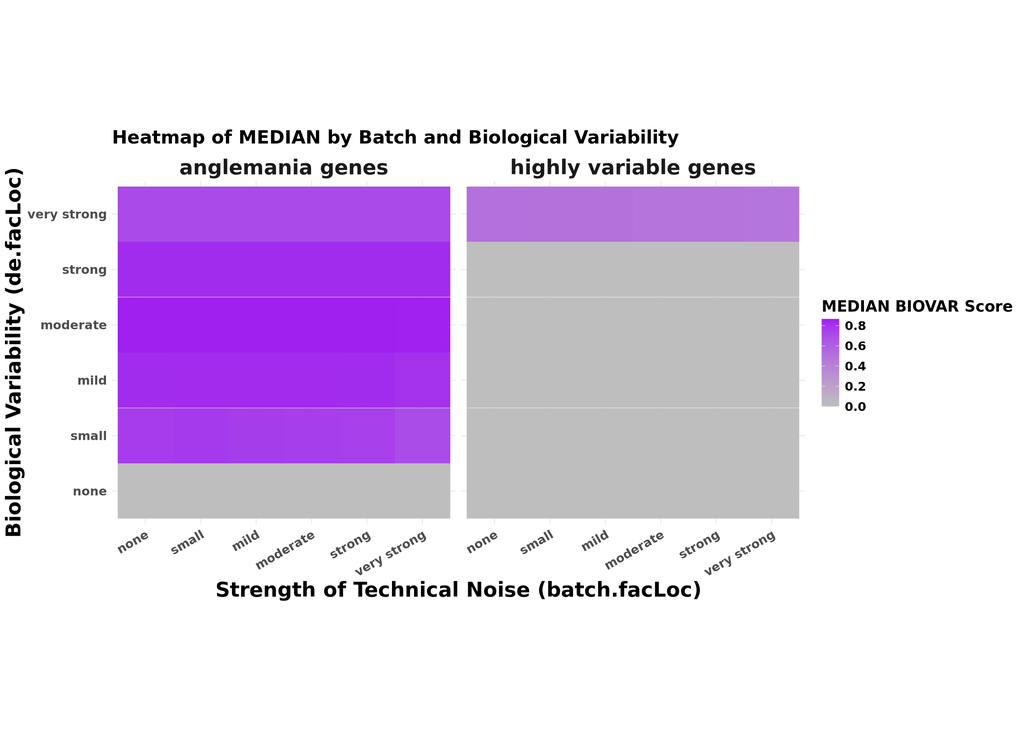

```r
p <- unnested %>%
  draw_heatmap2(
    df = .,
    score = "BioVar",
    fill = "median"
  )

p
```

```r
ggsave(
  file.path(outplot, glue("{today()}_median_BioVar_heatmap.pdf")),
  width = 11,
  height = 8
)
```

## raw_BioVar

- it looks like the higher BTVR is due to the fact that angelmania captures genes with high biological variability!

### Mean

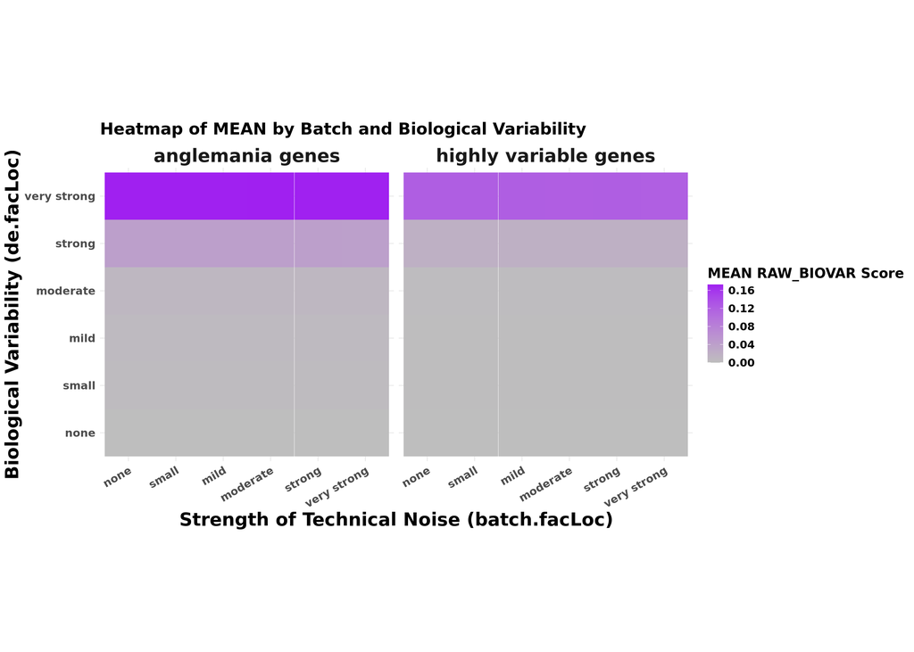

```r
p <- unnested %>%
  draw_heatmap2(
    df = .,
    score = "raw_BioVar",
    fill = "mean"
  )

p
```

```r
ggsave(
  file.path(outplot, glue("{today()}_mean_rawBioVar_heatmap.pdf")),
  width = 11,
  height = 8
)
```

### Median

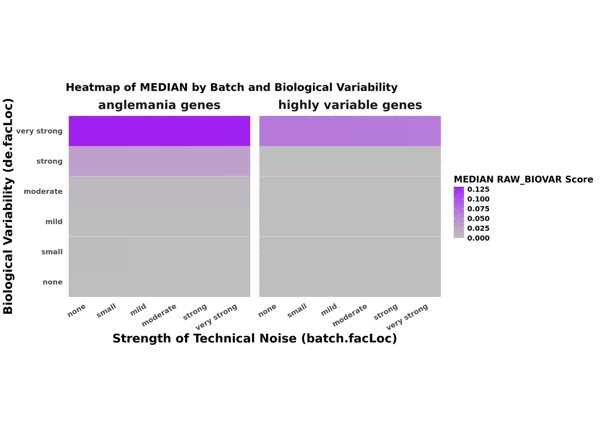

```r
p <- unnested %>%
  draw_heatmap2(
    df = .,
    score = "raw_BioVar",
    fill = "median"
  )

p
```

```r
ggsave(
  file.path(outplot, glue("{today()}_median_rawBioVar_heatmap.pdf")),
  width = 11,
  height = 8
)
```

## TechVar

- However it still captures genes with high technical variability, just like HVGs, with increasing Technical Variability / Batch effects

### Mean

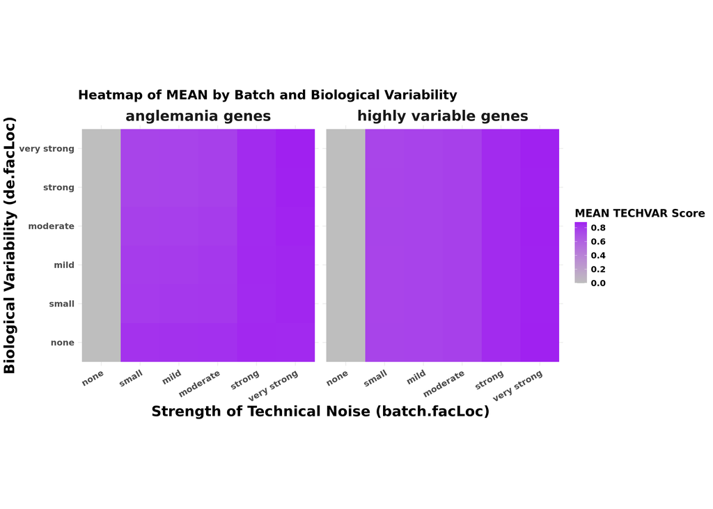

```r
p <- unnested %>%
  draw_heatmap2(
    df = .,
    score = "TechVar",
    fill = "mean"
  )

p
```

```r
ggsave(
  file.path(outplot, glue("{today()}_mean_TechVar_heatmap.pdf")),
  width = 11,
  height = 8
)
```

### Median

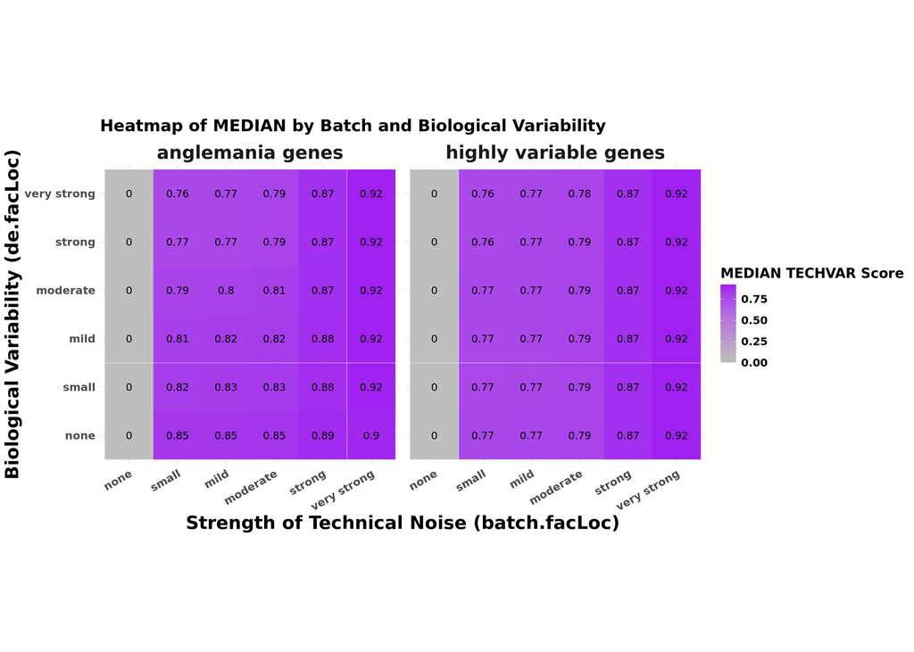

```r
p <- unnested %>%
  draw_heatmap2(
    df = .,
    score = "TechVar",
    fill = "median",
    add_geom_text = TRUE
  )

p
```

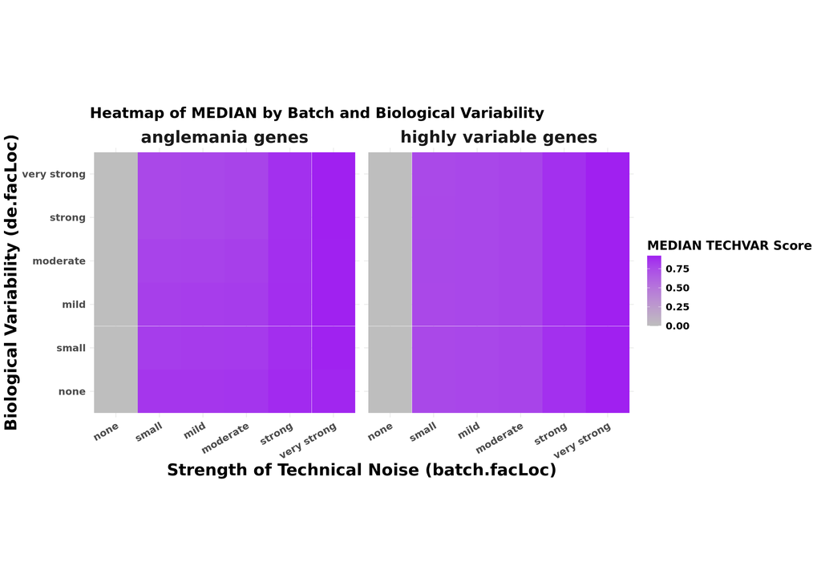

```r
p <- unnested %>%
  draw_heatmap2(
    df = .,
    score = "TechVar",
    fill = "median"
  )

p
```

```r
ggsave(
  file.path(outplot, glue("{today()}_median_TechVar_heatmap.pdf")),
  width = 11,
  height = 8)
```

## rawTechVar

- However it still captures genes with high technical variability, just like HVGs, with increasing Technical Variability / Batch effects

### Mean

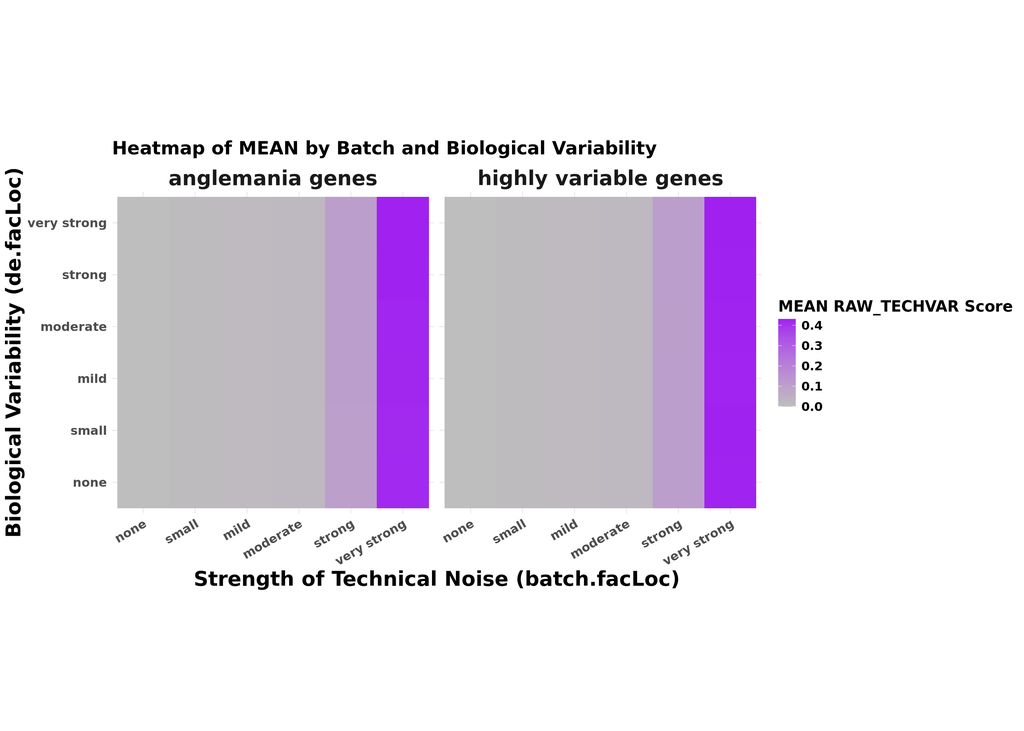

```r
p <- unnested %>%
  draw_heatmap2(
    df = .,
    score = "raw_TechVar",
    fill = "mean"
  )
p
```

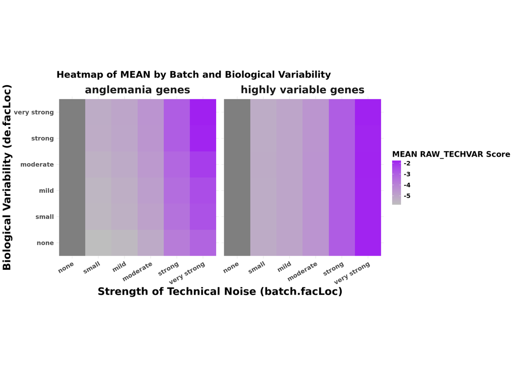

```r
p <- unnested %>%
  mutate(raw_TechVar = log(raw_TechVar)) %>%
  draw_heatmap2(
    df = .,
    score = "raw_TechVar",
    fill = "mean"
  )
p
```

```r
ggsave(
  file.path(outplot, glue("{today()}_mean_rawlogTechVar_heatmap.pdf")),
  width = 11,
  height = 8
)
```

### Median

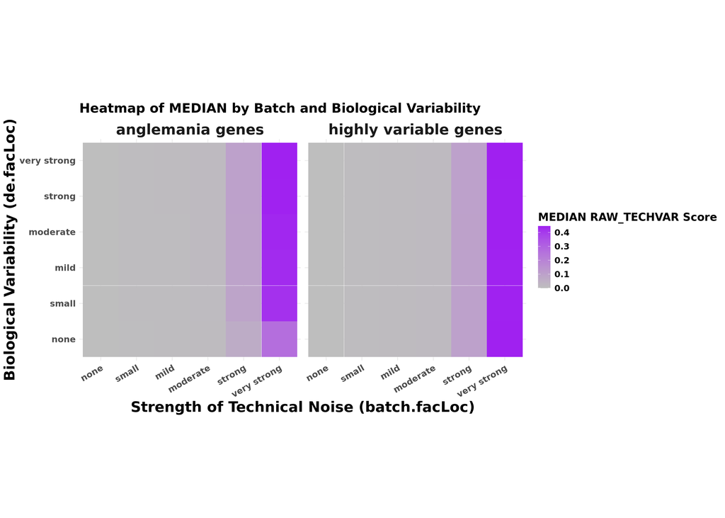

```r
p <- unnested %>%
  draw_heatmap2(
    df = .,
    score = "raw_TechVar",
    fill = "median"
  )
p
```

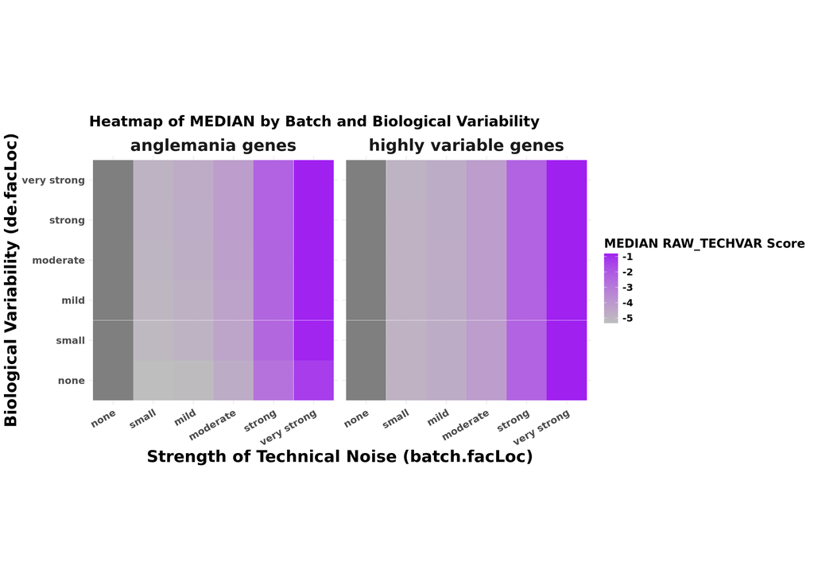

```r
p <- unnested %>%
  mutate(raw_TechVar = log(raw_TechVar)) %>%
  draw_heatmap2(
    df = .,
    score = "raw_TechVar",
    fill = "median"
  )

p
```

```r
ggsave(
  file.path(outplot, glue("{today()}_median_rawlogTechVar_heatmap.pdf")),
  width = 11,
  height = 8)
```

# Statistical tests